# Datos ordinales 1

Moises

2/3/2020

## Los datos ordinales

Los datos ordinales son parecidos a los cualitativos, en el sentido de que son cualidades de los individuos u objetos.

La diferencia existente entre los datos cualitativos y los ordinales reside en las características que expresan. En el caso de los ordinales, éstas tienen un orden natural que permite “acumular” observaciones.

## Frecuencia acumulada

Al trabajar con datos ordinales, el orden de los niveles de los datos nos permite calcular no solo frecuencias absolutas y relativas, sino también frecuencias acumuladas.

Es decir, podemos contar cuantas veces hemos observado un dato menor o igual a este.

### Ejemplo 1

Suponed que tenemos una muestra de 15 estudiantes de los cuales sabemos su nota en el examen de Estadística. Clasificamos todos estos resultados en Suspenso (S ), Aprobado (A), Notable (N) y Excelente (Ex) y consideramos su orden natural S<A<N<Ex

.

Las notas obtenidas han sido las siguientes S, A, N, Ex, S, S, Ex, Ex, N, A, A, A, A, N, S

Como recordaréis, para saber cuantas hay de cada una (su frecuencia absoluta), utilizamos la función table()

```r
notas = ordered(c("S","A", "N", "Ex", "S", "S", "Ex", "Ex", "N", "A", "A", "A",
                  "A", "N", "S"), levels = c("S", "A", "N", "Ex"))
table(notas)
```

```
## notas
##  S  A  N Ex
##  4  5  3  3
```

En lo referente a frecuencias absolutas acumuladas, hay - 4 estudiantes con S o menos.

- Ello implica que la frecuencia acumulada de S es 4 9 estudiantes que han obtenido A o menos.
- Entonces, la frecuencia acumulada de A es 9 12 estudiantes los cuales han obtenido N o menos. Así, la frecuencia acumulada de N es 12
- 15 estudiantes (todos) que han obtenido Ex o menos. De este modo, la frecuencia acumulada de Ex es 15, o sea, el total.

## Frecuencia relativa acumulada.

Es la fracción del total de las observaciones en tanto por 1 que representa su frecuencia absoluta acumulada

Así, las frecuencias relativas acumuladas respectivas son: - S: 415≈ 0.27 - A: 915≈ 0.6 - N: 1215≈ 0.8 - Ex: 1515=1

### Ejemplo 2

En un estudio, a un grupo de clientes de un restaurante se les hizo la siguiente pregunta:

“¿Estás contento con el trato ofrecido por los trabajadores del establecimiento?”

Las posibles respuestas forman una escala ordinal con 1<2<3<4<5

```r
set.seed(2018)
clientes = sample(1:5, 50, replace = TRUE)
clientes
```

```
##  [1] 3 4 5 2 5 1 3 4 2 4 3 3 1 1 5 3 1 3 3 5 1 4 2 5 3 4 5 1 2 2 1 5 5 2 1 2 5 5
## [39] 2 1 2 1 3 2 1 2 3 3 1 2
```

```r
set.seed(NULL)
```

Ejercicio. Calculad todas las frecuencias y comprobad que son exactamente estas.

```r
table(clientes) #Absoluta
```

```
## clientes
##  1  2  3  4  5
## 12 12 11  5 10
```

```r
prop.table(table(clientes)) #Relativa
```

```
## clientes
##    1    2    3    4    5
## 0.24 0.24 0.22 0.10 0.20
```

```r
cumsum(table(clientes)) #Absoluta Acumulada
```

```
##  1  2  3  4  5
## 12 24 35 40 50
```

```r
cumsum(prop.table(table(clientes))) #Relativa Acumulada
```

```
##    1    2    3    4    5
## 0.24 0.48 0.70 0.80 1.00
```

## Descripción de datos ordinales con R Función cumsum()

¿Recordáis la función cumsum()? Pues esta puede ser utilizada a la hora de calcular frecuencias acumuladas.

Retomemos el ejemplo anterior de las notas de los estudiantes y calculemos y representemos en un diagrama de barras las frecuencias acumuladas de la muestra de notas.

```r
notas
```

```
##  [1] S  A  N  Ex S  S  Ex Ex N  A  A  A  A  N  S
## Levels: S < A < N < Ex
```

```r
fAbs = table(notas) #Frec. abs.
cumsum(fAbs) #Frec. abs. acumuladas
```

```
##  S  A  N Ex
##  4  9 12 15
```

```r
cumsum(prop.table(fAbs)) #Frec. relativas acumuladas
```

```
##         S         A         N        Ex
## 0.2666667 0.6000000 0.8000000 1.0000000
```

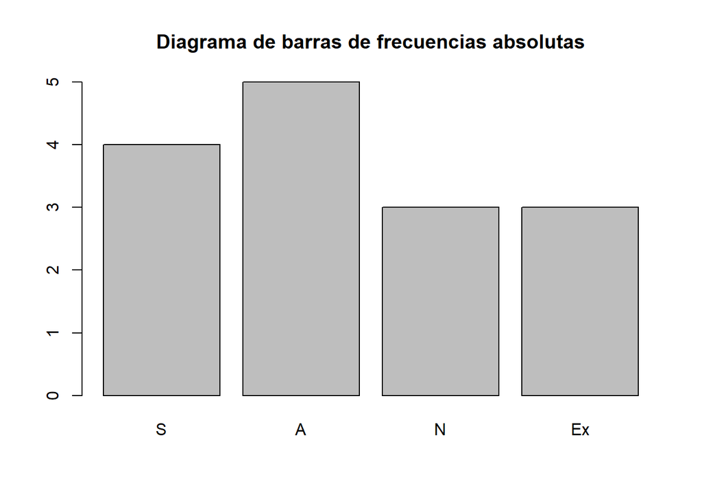

```r
barplot(fAbs, main = "Diagrama de barras de frecuencias absolutas")
```

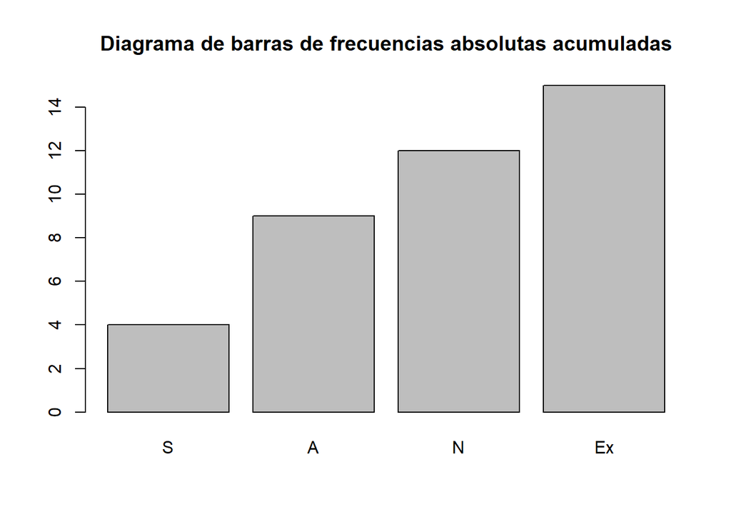

```r
barplot(cumsum(fAbs), main = "Diagrama de barras de frecuencias absolutas acumuladas")
```

```r
cumsum(table(notas))/length(notas) #Podríamos tambien haber calculado las frecuencias relativas acumuladas de la forma
```

```
##         S         A         N        Ex
## 0.2666667 0.6000000 0.8000000 1.0000000
```

```r
#Pero NO podemos hacer prop.table(cumsum(table(notas))).
```

## Tablas multidimensionales

Función cumsum()

Para calcular frecuencias acumuladas en una tabla multidimensional, hay que aplicar a la tabla la función cumsum mediante la función apply que ya explicábamos para matrices. En este caso en concreto, la sintaxis de la instrucción sería

apply(tabla, MARGIN=…, FUN=cumsum)

donde el valor MARGIN ha de ser el de la dimensión en la que queremos acumular las frecuencias: 1 si queremos hacerlo por filas, 2 para hacerlo por columnas, etc. Lo veremos todo más claro con un ejemplo

## Ejemplo 3

Vamos a organizar todos estos datos en un data frame llamado jirafas. Para que nos sea más fácil visualizar la información, es conveniente que las filas de las tablas de frecuencias correspondan a las zonas. Por lo tanto, al definir el data frame, entraremos como primera variable la de la muestra las zonas. Así, conseguiremos que éstas aparezcan en las filas al aplicarle la función table.

```r
zonas = rep(c("A","B","C","D"), c(30,25,35,10))
longitud = rep(c("Muy.corto","Corto","Normal","Largo","Muy.largo"), c(25,21,19,18,17))
jirafas = data.frame(zonas,longitud)
str(jirafas)
```

```
## 'data.frame':    100 obs. of  2 variables:
##  $ zonas   : Factor w/ 4 levels "A","B","C","D": 1 1 1 1 1 1 1 1 1 1 ...
##  $ longitud: Factor w/ 5 levels "Corto","Largo",..: 3 3 3 3 3 3 3 3 3 3 ...
```

```r
head(jirafas)
```

```
##   zonas  longitud
## 1     A Muy.corto
## 2     A Muy.corto
## 3     A Muy.corto
## 4     A Muy.corto
## 5     A Muy.corto
## 6     A Muy.corto
```

Para calcular la tabla de frecuencias absolutas acumuladas de las longitudes por zonas y como las zonas definen las filas de la tabla anterior, debemos utilizar la función apply con MARGIN = 1.

```r
apply(table(jirafas), MARGIN = 1, FUN = cumsum)
```

```
##            zonas
## longitud     A  B  C  D
##   Corto      5 16  0  0
##   Largo      5 16 18  0
##   Muy.corto 30 16 18  0
##   Muy.largo 30 16 25 10
##   Normal    30 25 35 10
```

Fijaos que la tabla se ha traspuesto. Resulta que cuando se aplica apply a una table bidimensional, R intercambia, en caso de ser necesario, filas por columnas en el resultado para que la dimensión de la tabla resultante en la que se haya aplicado la función sea la de las columnas.

Con lo cual, para volver a tener las zonas en las filas, hay que trasponer el resultado de la función apply.

```r
t(apply(table(jirafas), MARGIN = 1, FUN = cumsum))
```

```
##      longitud
## zonas Corto Largo Muy.corto Muy.largo Normal
##     A     5     5        30        30     30
##     B    16    16        16        16     25
##     C     0    18        18        25     35
##     D     0     0         0        10     10
```

Vamos ahora a calcular la tabla de frecuencias relativas acumuladas de las longitudes de cuello por zonas. Para conseguirlo, y en una única instrucción, primero calculamos la tabla de frecuencias relativas por filas, a continuación, con las funciones apply y cumsum las acumulamos y, finalmente, trasponemos el resultado.

```r
t(apply(prop.table(table(jirafas), margin = 1), MARGIN = 1, FUN = cumsum)) #Para hacer que las columnas y filas se inviertan
```

```
##      longitud
## zonas     Corto     Largo Muy.corto Muy.largo Normal
##     A 0.1666667 0.1666667 1.0000000 1.0000000      1
##     B 0.6400000 0.6400000 0.6400000 0.6400000      1
##     C 0.0000000 0.5142857 0.5142857 0.7142857      1
##     D 0.0000000 0.0000000 0.0000000 1.0000000      1
```

Vamos ahora a dibujar el diagrama de barras por bloques de esta tabla. Nos interesa que las barras de este diagrama se agrupen por zonas. Entonces, tendremos que aplicar barplot a la tabla sin trasponer.

Además, vamos a colocar la leyenda en la esquina superior izquierda para que no se superponga a ninguna barra. También reduciremos el tamaño del texto de la leyenda para que quepa completamente.

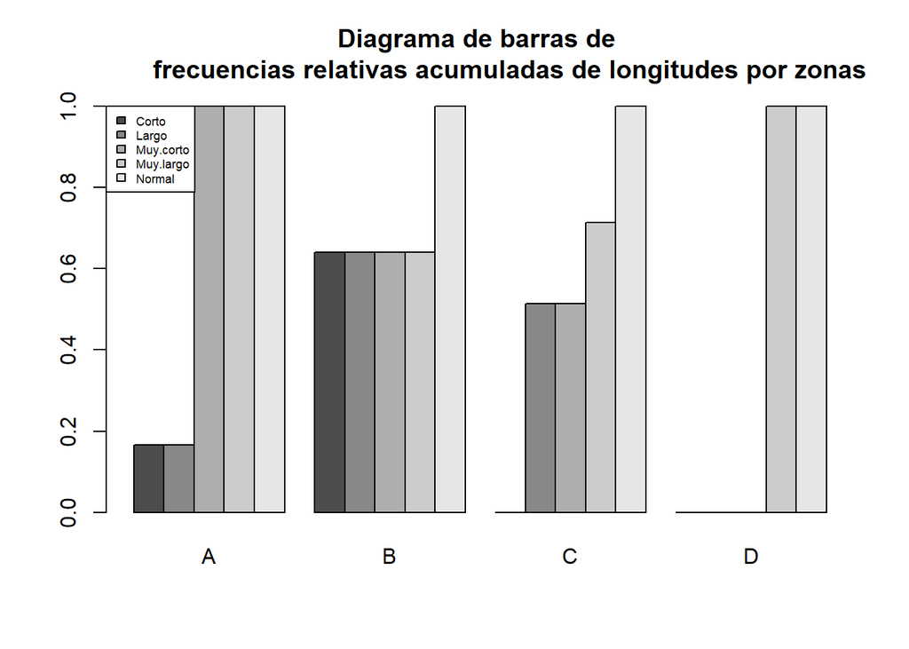

```r
Diagrama = apply(prop.table(table(jirafas), margin = 1), MARGIN = 1, FUN = cumsum)
barplot(Diagrama, beside = TRUE, legend = TRUE, main = "Diagrama de barras de
        frecuencias relativas acumuladas de longitudes por zonas",
args.legend=list(x="topleft", cex=0.55)) #cex es para indicar el tamaño de la letra del legend
```

## Ejemplo 5

Consideremos el data frame datacrab y arreglemos los datos.

```r
crabs = read.table("../data/datacrab.txt", header = TRUE)
crabs = crabs[,-1] #Omitimos la primera columna, ya que no me interesa
str(crabs)
```

```
## 'data.frame':    173 obs. of  5 variables:
##  $ color : int  3 4 2 4 4 3 2 4 3 4 ...
##  $ spine : int  3 3 1 3 3 3 1 2 1 3 ...
##  $ width : num  28.3 22.5 26 24.8 26 23.8 26.5 24.7 23.7 25.6 ...
##  $ satell: int  8 0 9 0 4 0 0 0 0 0 ...
##  $ weight: int  3050 1550 2300 2100 2600 2100 2350 1900 1950 2150 ...
```

```r
table(crabs$width)
```

```
##
##   21   22 22.5 22.9   23 23.1 23.2 23.4 23.5 23.7 23.8 23.9   24 24.1 24.2 24.3
##    1    1    3    3    2    3    1    1    1    3    3    1    2    1    2    2
## 24.5 24.7 24.8 24.9   25 25.1 25.2 25.3 25.4 25.5 25.6 25.7 25.8 25.9   26 26.1
##    7    5    1    3    6    2    2    1    3    3    2    6    7    1    6    2
## 26.2 26.3 26.5 26.7 26.8   27 27.1 27.2 27.3 27.4 27.5 27.6 27.7 27.8 27.9   28
##    8    1    6    3    3    5    2    2    1    3    6    1    2    2    2    3
## 28.2 28.3 28.4 28.5 28.7 28.9   29 29.3 29.5 29.7 29.8   30 30.2 30.3 30.5 31.7
##    4    3    2    4    2    1    6    2    1    1    1    3    1    1    1    1
## 31.9 33.5
##    1    1
```

Vamos a convertir a la variable width en una variable ordinal que agrupe las entradas de la variable original en niveles.

La manera más sencilla de llevarlo a cabo es utilizando la función cut, que estudiaremos en detalle en lecciones posteriores. Por ahora, basta con saber que la instrucción dividirá el vector numérico crabs$width en intervalos de extremos los puntos especificados en el argumento breaks. El parámetro right = FALSE sirve para indicar que los puntos de corte pertenecen la intervalo de su derecha, e Inf indica ∞.

Por lo tanto, nosotros llevaremos a cabo la siguiente instrucción

```r
intervalos = cut(crabs$width, breaks = c(21,25,29,33,Inf), right = FALSE,
                 labels = c("21-25", "25-29", "29-33", "33-..."))

#El parametro right quiere decir que si es FALSE el mismo NO va a incluir el elemento de la derecha osea de 21,25 el NO va a incluir a 25 pero si a 21. Cuando es TRUE, se incluye a 25 pero NO a 21
```

El resultado de la instrucción es un factor que tiene como niveles estos intervalos, identificados con las etiquetas especificadas en el parámetro labels. Como nostros vamos a usar estos intervalos como niveles de una variable ordinal, además convertiremos este factor en ordenado.

```r
crabs$width.rank = ordered(intervalos)
str(crabs)
```

```
## 'data.frame':    173 obs. of  6 variables:
##  $ color     : int  3 4 2 4 4 3 2 4 3 4 ...
##  $ spine     : int  3 3 1 3 3 3 1 2 1 3 ...
##  $ width     : num  28.3 22.5 26 24.8 26 23.8 26.5 24.7 23.7 25.6 ...
##  $ satell    : int  8 0 9 0 4 0 0 0 0 0 ...
##  $ weight    : int  3050 1550 2300 2100 2600 2100 2350 1900 1950 2150 ...
##  $ width.rank: Ord.factor w/ 4 levels "21-25"<"25-29"<..: 2 1 2 1 2 1 2 1 1 2 ...
```

Nos interesa estudiar la distribución de las anchuras de los cangrejos según el número de colores. Por lo tanto, vamos a calcular las tablas bidimensionales de frecuencais relativas y relativas acumuladas de los intervalos de las anchuras en cada nivel de color y las representaremos por medio de diagramas de barras.

La tabla de frecuencias absolutas de los pares se puede obtener aplicando table al data frame formado por la primera y última columnas.

```r
Tabla = table(crabs[,c(1,6)])
Tabla
```

```
##      width.rank
## color 21-25 25-29 29-33 33-...
##     2     1     9     2      0
##     3    19    62    13      1
##     4    17    24     3      0
##     5     9    12     1      0
```

```r
Fr.rel = round(prop.table(Tabla,margin = 1),3)
Fr.rel
```

```
##      width.rank
## color 21-25 25-29 29-33 33-...
##     2 0.083 0.750 0.167  0.000
##     3 0.200 0.653 0.137  0.011
##     4 0.386 0.545 0.068  0.000
##     5 0.409 0.545 0.045  0.000
```

```r
Fr.rel.acu = round(apply(prop.table(Tabla, margin = 1), MARGIN = 1, FUN = cumsum), 3)
t(Fr.rel.acu)
```

```
##      width.rank
## color 21-25 25-29 29-33 33-...
##     2 0.083 0.833 1.000      1
##     3 0.200 0.853 0.989      1
##     4 0.386 0.932 1.000      1
##     5 0.409 0.955 1.000      1
```

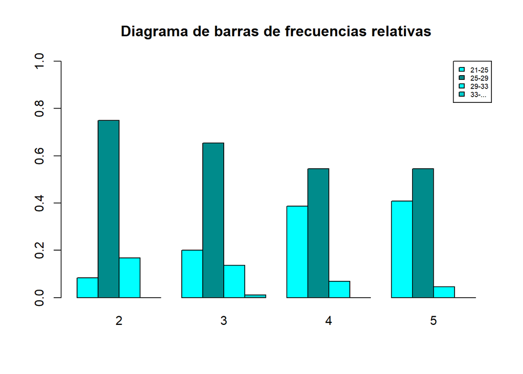

```r
azul = c("cyan", "cyan4", "cyan1", "cyan3")

barplot(t(Fr.rel), beside = TRUE, legend = TRUE, ylim = c(0,1), col = azul,
        main = "Diagrama de barras de frecuencias relativas",
        args.legend=list(x = "topright", cex=0.55))
```

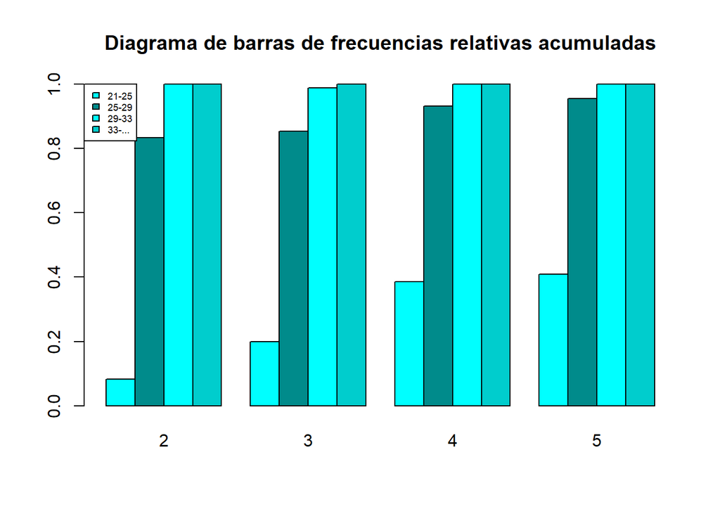

```r
barplot(Fr.rel.acu, beside = TRUE, legend = TRUE, col = azul,
        main = "Diagrama de barras de frecuencias relativas acumuladas",
        args.legend=list(x = "topleft", cex=0.55))
```